# HW3

2022-04-05

## Introduction

Last year at a global climate summit, the Intergovernmental Panel on Climate Change (IPCC) declared the effects of climate change irreversable. This may not come as a surprise; it seems that every day a new report is declaring the current week, month, or year the hottest, dryest, weirdest on record. But what does it mean that a given year, week, or day is the hottest on record? How is climate data quantified, and what should we think when we hear such reports? In this report an attempt is made to break down this question and answer it in a way that can be easily comprehended.

1. Is Utah drier than it was 80 years ago?
2. What is the average low temperature in Salt Lake City in January?
3. What is the “hottest year” on record in Utah?
4. What is the “coldest year” on record in Utah?

In an attempt to digest these questions, data made publicly available from the National Oceanic and Atmospheric Association (NOAA) is used. From the documentation of the report being used, “…the GHCN-Daily is a composite of climate records from numerous sources that were merged and then subjected to a suite of quality assurance reviews. The archive includes over 40 meteorological elements including temperature daily maximum/minimum, temperature at observation time, precipitation, snowfall, snow depth, evaporation, wind movement, wind maximums, soil temperature, cloudiness, and more.” “GHCN (Global Historical Climatology Network) – Daily Documentation” (n.d.)

## Process

To answer these questions, we examine the relevant data data collected from 2021, and compare it to the same data of 1941. This type of direct comparison isn’t the most accurate methodology to use. A better sample would include samples from several years before and after the target years, to minimize the possibility of these two years being an outlier in a larger data set. Unfortunately, bandwidth constraints imposed on NOAA’s website, along with processing constraints on the author’s machine, make such an analysis impractical. Therefore, the evidence examined herein should be used strictly for a frame of reference and not as an extensive analysis.

## Question 1: Is utah drier today than it was 80 years ago?

This will be an exceedingly difficult question to answer with our current data set. The temperature data for the year 1941 was collected only for Salt Lake City. For this reason, we will restrict our sample to Salt Lake City for both data sets to not skew the results.

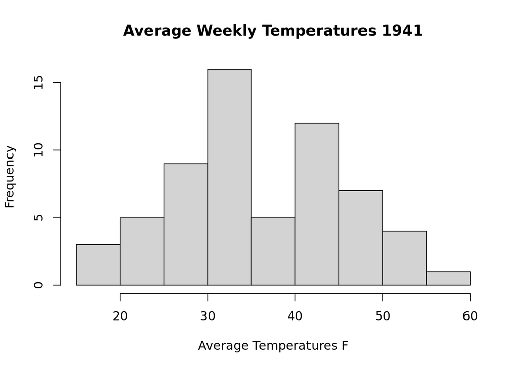

```r
past_avg <- filter(select(past_data, TAVG), !is.na(TAVG))
current_avg <- select(filter(select(current_data, TAVG, NAME), NAME == "SALT LAKE CITY INTERNATIONAL AIRPORT, UT US", !is.na(TAVG)), TAVG)
hist(past_avg$TAVG, xlab="Average Temperatures F", main="Average Weekly Temperatures 1941")
```

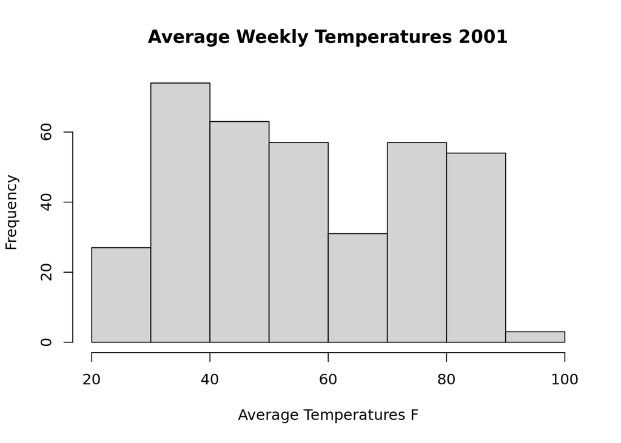

```r
hist(current_avg$TAVG, xlab="Average Temperatures F", main="Average Weekly Temperatures 2001")
```

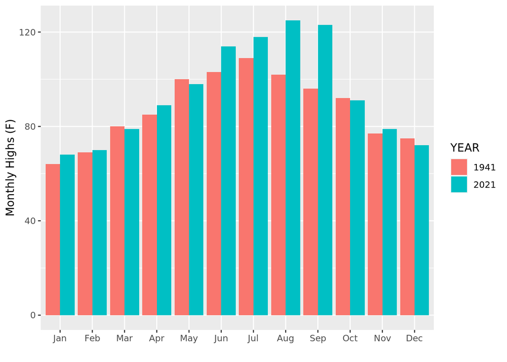

```r
max_1941 <- unique(select(past_data, TMAX, DATE) %>%
  group_by(MONTH=month(floor_date(as.Date(DATE), "month"), label=T, abbr = T)) %>%
  mutate(
    MAX_BY_MONTH = max(TMAX, na.rm = T),
    YEAR = "1941"
  ) %>% select(MONTH, YEAR, MAX_BY_MONTH))

max_2021 <- unique(select(current_data, TMAX, DATE) %>%
  group_by(MONTH=month(floor_date(as.Date(DATE), "month"), label=T, abbr = T)) %>%
  mutate(
    MAX_BY_MONTH = max(TMAX, na.rm = T),
    YEAR="2021"
  ) %>% select(MONTH, YEAR, MAX_BY_MONTH))

# Min values

min_1941 <- unique(select(past_data, TMIN, DATE) %>%
  group_by(MONTH=month(floor_date(as.Date(DATE), "month"), label=T, abbr = T)) %>%
  mutate(
    MIN_BY_MONTH = min(TMIN, na.rm = T),
    YEAR = "1941"
  ) %>% select(MONTH, YEAR, MIN_BY_MONTH))

min_2021 <- unique(select(current_data, TMIN, DATE) %>%
  group_by(MONTH=month(floor_date(as.Date(DATE), "month"), label=T, abbr = T)) %>%
  mutate(
    MIN_BY_MONTH = min(TMIN, na.rm = T),
    YEAR="2021"
  ) %>% select(MONTH, YEAR, MIN_BY_MONTH))


ggplot(rbind(max_1941, max_2021)) +
    geom_bar(position="dodge", stat="identity", mapping = aes(fill=YEAR, y=MAX_BY_MONTH, x=MONTH)) +
    ylab("Monthly Highs (F)") +
    xlab("")
```

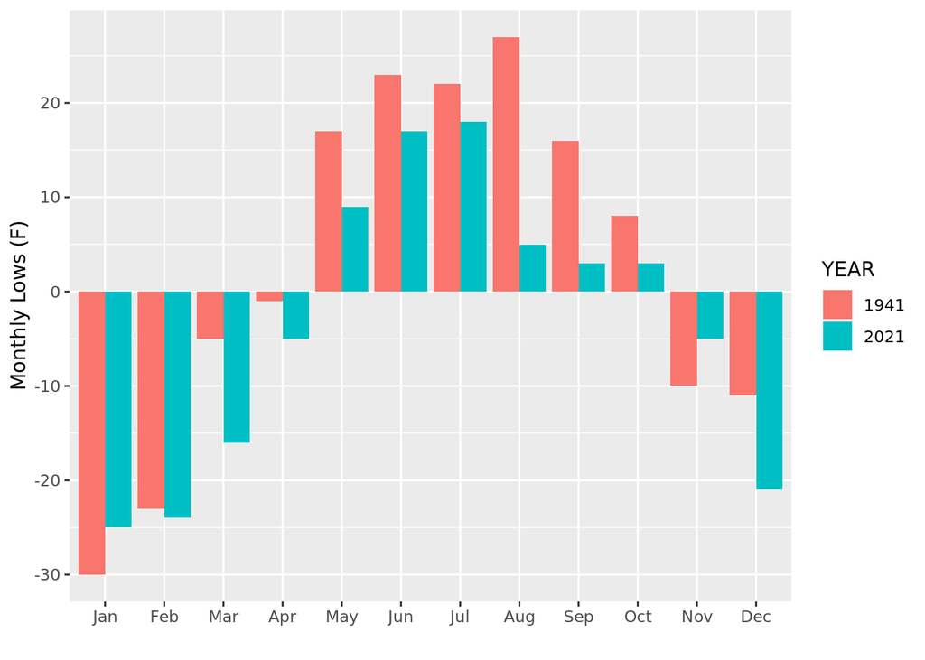

```r
ggplot(rbind(min_1941, min_2021)) +
    geom_bar(position="dodge", stat="identity", mapping = aes(fill=YEAR, y=MIN_BY_MONTH, x=MONTH)) +
    ylab("Monthly Lows (F)") +
    xlab("")
```

## Question 2: What is the average low temperature in January in Salt Lake City?

To answer this question is pretty straight forward. We will examine the lows of each day in January 2021 and January 1941, and perform a simple average over the data.

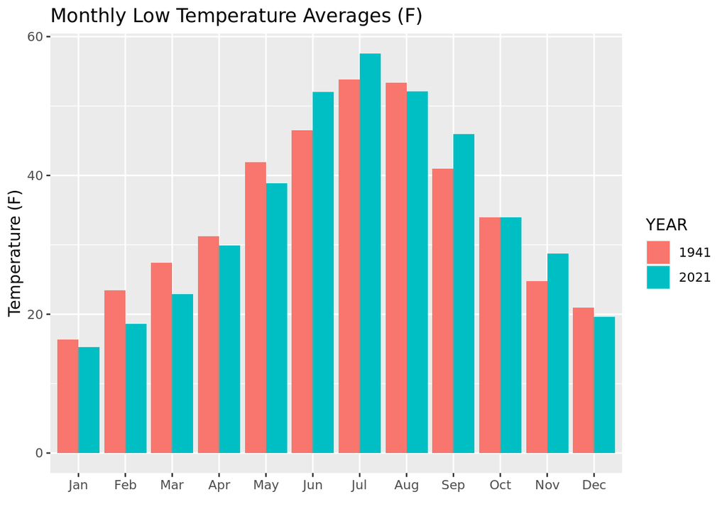

```r
avg_lows_1941 <- unique(select(past_data, TMIN, DATE) %>%
  group_by(MONTH=month(floor_date(as.Date(DATE), "month"), label=T, abbr = T)) %>%
    summarize_at(.vars = dplyr::vars(TMIN), list(MEAN=function(t) mean(t,na.rm = T)))
  ) %>% mutate(
    YEAR = "1941"
  )

avg_lows_2021 <- unique(select(current_data, TMIN, DATE) %>%
  group_by(MONTH=month(floor_date(as.Date(DATE), "month"), label=T, abbr = T)) %>%
    summarize_at(.vars = dplyr::vars(TMIN), list(MEAN=function(t) mean(t,na.rm = T)))
  ) %>% mutate(
    YEAR = "2021"
  )

ggplot(rbind(avg_lows_1941, avg_lows_2021)) +
    geom_bar(position="dodge", stat="identity", mapping = aes(fill=YEAR, y=MEAN, x=MONTH)) +
    labs(title = "Monthly Low Temperature Averages (F)") +
    xlab("") +
    ylab("Temperature (F)")
```

In January the average temperature was approximately 15 degrees in 2021, plus or minus about 1/20th of a degree. In 1941 the average temperature was approximately 16 degrees. The data here also shows a similar trend of an overall shifting of the colder temperatures and warmer temperatures.

## Question 3: What is the “hottest year” on record in Utah?

According to NOAA national centers for environmental information, 1934 is the hottest year on record in Utah with an average annual temperature of 51.3 degrees F. To understand that better we’ll examine this year more closely.

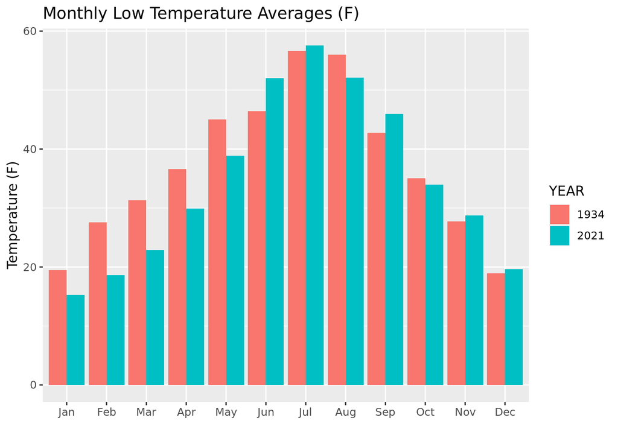

```r
avg_lows_1934 <- unique(select(hottest_data, TMIN, DATE) %>%
  group_by(MONTH=month(floor_date(as.Date(DATE), "month"), label=T, abbr = T)) %>%
    summarize_at(.vars = dplyr::vars(TMIN), list(MEAN=function(t) mean(t,na.rm = T)))
  )  %>% mutate(
    YEAR = "1934"
  )

avg_lows_2021 <- unique(select(current_data, TMIN, DATE) %>%
  group_by(MONTH=month(floor_date(as.Date(DATE), "month"), label=T, abbr = T)) %>%
    summarize_at(.vars = dplyr::vars(TMIN), list(MEAN=function(t) mean(t,na.rm = T)))
  ) %>% mutate(
    YEAR = "2021"
  )

avg_highs_1934 <- unique(select(hottest_data, TMAX, DATE) %>%
  group_by(MONTH=month(floor_date(as.Date(DATE), "month"), label=T, abbr = T)) %>%
    summarize_at(.vars = dplyr::vars(TMAX), list(MEAN=function(t) mean(t,na.rm = T)))
  )  %>% mutate(
    YEAR = "1934"
  )

avg_highs_2021 <- unique(select(current_data, TMAX, DATE) %>%
  group_by(MONTH=month(floor_date(as.Date(DATE), "month"), label=T, abbr = T)) %>%
    summarize_at(.vars = dplyr::vars(TMAX), list(MEAN=function(t) mean(t,na.rm = T)))
  ) %>% mutate(
    YEAR = "2021"
  )

ggplot(rbind(avg_lows_1934, avg_lows_2021)) +
    geom_bar(position="dodge", stat="identity", mapping = aes(fill=YEAR, y=MEAN, x=MONTH)) +
    labs(title = "Monthly Low Temperature Averages (F)") +
    xlab("") +
    ylab("Temperature (F)")
```

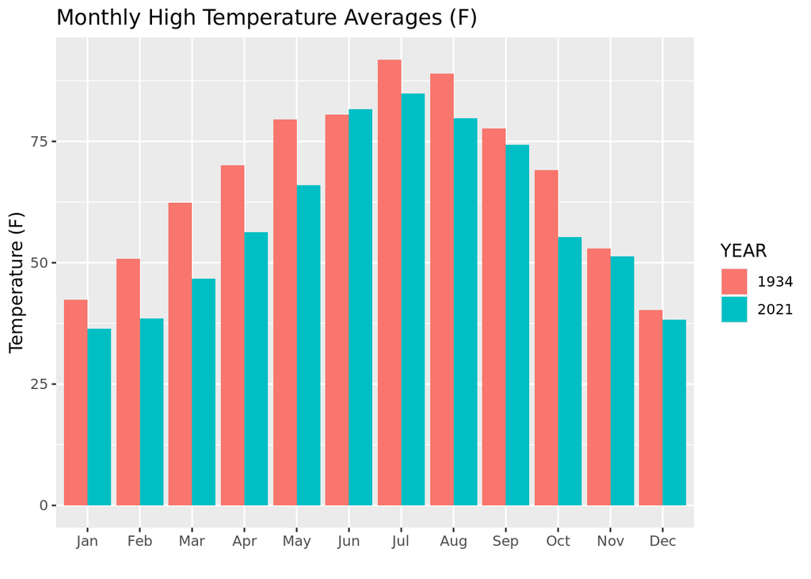

```r
ggplot(rbind(avg_highs_1934, avg_highs_2021)) +
    geom_bar(position="dodge", stat="identity", mapping = aes(fill=YEAR, y=MEAN, x=MONTH)) +
    labs(title = "Monthly High Temperature Averages (F)") +
    xlab("") +
    ylab("Temperature (F)")
```

## Question 4: What is the “coldest year” on record in Utah?

I wasn’t able to find the coldest year on record in Utah. I searched through several years, but I wasn’t able to download enough data to filter all through all the data. The coldest day on record (-69 degrees F) was February 1, 1985 recorded in Peter Sinks.

“GHCN (Global Historical Climatology Network) – Daily Documentation.” n.d. *Datasets | Climate Data Online (CDO) | National Climatic Data Center (NCDC)*. https://www1.ncdc.noaa.gov/pub/data/cdo/documentation/GHCND_documentation.pdf.